# Introduction

Environmental and Natural Resource Economics in a Global Framing

# Resources

[video not shown]

[01 Slides - Introduction - Environmental and Natural Resource Economics in a Global Framing](https://drive.google.com/file/d/1cImgQKhuLocr_VorToBju8VIiCSKziQj/view?usp=sharing)

# Content

## The Big Picture: Why Environmental Economics Matters

### The Importance of the Environment

This course will approach environmental economics from the perspective that the environment matters and that saving the environment matters.

### Historical Climate Context

#### The Last 100,000 Years of Temperature

A graph of Earth’s surface temperature for the last 100,000 years reveals two critical observations. First, there were wild swings in temperature as glaciation occurred, with temperatures fluctuating significantly. Second, it was considerably cooler before modern times. These massive fluctuations and cooler temperatures characterized most of this period.

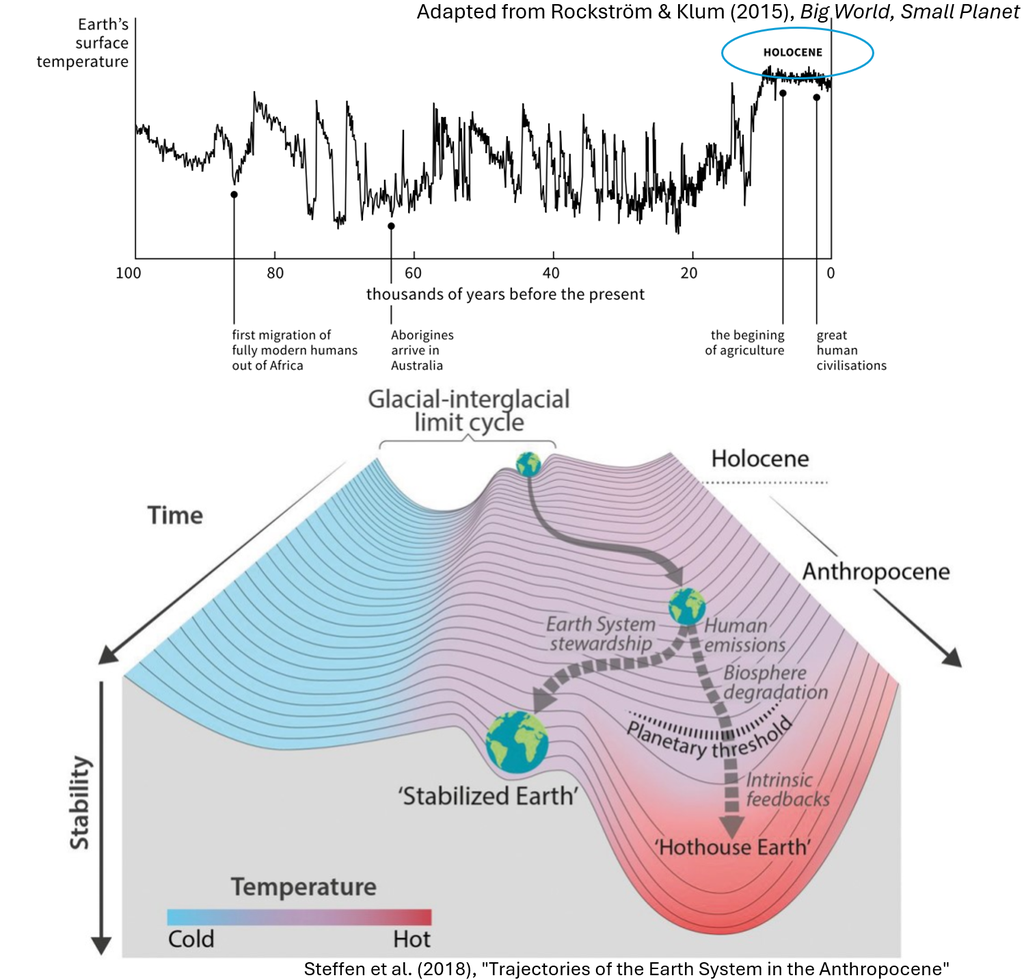

#### The Holocene Era

We currently exist in this unique and special Goldilocks zone, which is extremely beneficial but also emphasizes the importance of remaining within this stable region. There is reason for concern about our continued stability in this zone.

### The Anthropocene Concept

Some scientists argue that we are on the edge of transitioning into a brand new ecological zone, leaving the Holocene and entering something called the Anthropocene. This concept has gained enough recognition to be featured on the cover of The Economist, which, while somewhat humorous as a form of scientific validation, does indicate the importance of this concept in economic discussions. There is considerable scientific debate about what actually constitutes a geologic era, but the underlying concern about significant environmental change remains valid.

### Understanding Climate Transitions

A three-dimensional representation of climate transitions helps frame the questions this course will address. This visualization shows three key dimensions: the passage of time, stability (which is decreasing), and global temperature. The stability dimension is analogous to a marble in a bowl, where the bottom of the bowl represents a stable point. Multiple stable points exist along the temperature spectrum.

Climate change is a fundamental basis of this course. The change that defined the Holocene, and what concerns us about modern-day anthropogenic climate change, will be examined through the lens of adaptation, understanding what climate change does to the sustainability of our economies.

#### Thresholds and Choices

The concept of thresholds is central to understanding the choices before us. We can think of humanity as being at a decision point where we have choices about how much to emit. Emitting a lot pushes us toward higher temperatures and more severe climate change, while we also have options for stabilizing the climate and pushing it in the opposite direction.

The concerning possibility is that feedback loops may exist, and there is substantial evidence that they do. Once we cross certain thresholds, the rate of change may accelerate, leading to a split in possible futures. One equilibrium, sometimes called Hothouse Earth, represents a world with significantly higher temperatures. Alternatively, we could avoid that planetary threshold by reducing emissions now and end up in a less ideal but still much better equilibrium that remains stable at lower temperatures.

This framing of how our decisions push us toward different equilibria will be used throughout the course, applying not just to temperature but to a variety of environmental factors.

## Planetary Boundaries Framework

### Introduction to Planetary Boundaries

The concept of planetary boundaries is one that is just beginning to gain public recognition. Scientists like Johann Rockstrom have been compelling speakers who can give TED Talks about these issues and motivate people to action. This framework expresses the potential peril we face, as illustrated by recent papers with titles like “Earth Beyond Six of Nine Planetary Boundaries.”

[figure not shown]

### Categories of Planetary Boundaries

While a detailed discussion of the science behind each boundary is more appropriate for an environmental science major, the main categories include climate change, biospheric integrity (another way of describing biodiversity loss or species loss), genetic integrity, and land systems change. The framework identifies a safe operating space represented by a green area. For some indicators, we have not yet surpassed the planetary boundary, but unfortunately for six of them, we are in a tenuous space beyond the boundary, essentially waiting for consequences to materialize.

### The Success Story: Ozone Depletion

This course will emphasize hopefulness, and the story of stratospheric ozone depletion provides a powerful example. The ozone hole was a serious problem that could have led to significant increases in skin cancer, but it was solved through collective action. Scientists identified that CFCs, a chemical used in refrigeration, were creating the ozone hole. The Montreal Protocol was developed and implemented, successfully addressing the problem. This is one planetary boundary that has not been surpassed, essentially because of successful collective action.

Some challenges are harder than the ozone problem. The ozone issue involved just one hole, one small spot, and one chemical. Other issues like climate change may be much more complex. However, the key takeaway is that collective action can solve these problems.

### Limitations of the Planetary Boundaries Framework

The planetary boundaries framework establishes that there are biophysical boundaries that should not be crossed, and we should tread carefully. The economy should not push these boundaries, and we need to understand the costs to the economy from surpassing them.

However, this framework has limitations. While it is a very popular framing, its primary effect may be to create fear. Fear and depression do not lead people to make positive change on the environment. It is important to know the status, but the framework is not very useful for guiding action. Additionally, it provides no information about what is pushing these variables around or what is causing us to possibly surpass the planetary boundaries.

## The Safe and Just Corridor: The Planetary Donut

### Introduction to the Donut Framework

The Safe and Just Corridor, also known as the Planetary Donut, provides a more complete framing. This framework maintains planetary boundaries while adding an important dimension: humans. The planetary boundaries framework only describes the biophysical state of the world without addressing the underlying people, their choices, and their well-being.

### Kate Raworth’s Contribution

The Planetary Donut was first introduced in 2017 by Kate Raworth. She refers to the planetary boundaries as the ecological ceiling but adds a critical layer called the social floor or foundation. The shape creates a donut, where for any indicator, we do not want to exceed the planetary boundary, but we also must ensure that we are producing the things necessary to create the social foundation.

[figure not shown]

### The Social Foundation

The social foundation includes essential elements such as producing enough food, having healthcare, and having a safe place to live. These are things produced by the economy. We do not want to do without them, which provides a way of moving beyond the idea that it is the economy versus the environment. Instead, the framework involves jointly optimizing trade-offs.

Some types of economic activity are harmful, like CFCs in refrigerants that caused the ozone hole. But there are also things we genuinely want, like universities or the option to have a safe and fulfilling, welfare-filled life. What this means in economic terms will be discussed throughout the course.

### Finding the Safe and Just Corridor

Kate Raworth’s central question concerns what policies can avoid falling below and undershooting on the production of key things we care about while also not overshooting and exceeding planetary boundaries. The goal is to identify how we can stay in the safe and just corridor.

In 2023, Kate Raworth published in Science the formal paper describing this framework with quantitative metrics in detail. There are now many ways to apply this framework, with various other donut-based analyses being developed as popular organizing principles.

### Limitations of the Donut Framework

The Planetary Donut framework is a significant improvement over planetary boundaries alone because it includes human agents in the system. However, it still does not answer fascinating questions like what should we do and what policies might get us into the safe and just corridor.

The framing throughout this class will be to analyze those policies. We need to understand the Earth’s systems at play to be smart enough to figure out what policies might work or what impact they would have, but the focus will be on the actual levers we can pull.

## The Role of Economics in Environmental Solutions

### The Tension Between Economics and Environmentalism

What is the economist’s role in solving environmental problems? This question arises frequently in discussions with ecologists, conservation biologists, and others less focused on economics as a discipline. There is often a feeling of needing to apologize for economics because the old framing of environmental economics was the environment versus the economy. This framing has been used by various interests in society to polarize people and discourage care about important environmental issues.

One side of this polarization comes from environmentalists who assume that anything an economist says will be bad because it relates to perfect markets, capitalism, and endless growth. These are important issues to address, but economics is actually an incredibly useful lens for examining environmental questions. It is not an either/or situation.

### The Success of Economics at Improving Physical Consumption

Economics has performed phenomenally well at improving physical consumption. Modern economics can be traced to right after World War II, when systems of national accounts were created to define, among other things, GDP.

GDP is now constantly reported and obsessed over, making and breaking presidents and policies. It was essentially a measure of how much the economy can produce, which is critically important during wartime when military success depends on literally producing tanks and other materials. It serves as a good measure for the well-being derived from physical consumption.

These systems of national accounts were navigational tools designed to help navigate out of the Great Depression. The course will cover specific tools that fit within this framework and address how they succeed or fail at simultaneously accounting for the value of nature and the value of production.

### Evidence of Economic Success

#### Poverty Reduction

It is easy to forget how significant the change has been in the last 100 years. From 1820 to 2015, the world population living in extreme poverty has decreased dramatically. In the earlier era, the probability of struggling to have enough calories to survive was 90 to 95 percent. Now it is the opposite, with a drastic reduction in poverty.

[figure not shown]

#### Life Expectancy

Life expectancy provides an even more compelling statistic. From 1770 to 2021, life expectancies at birth have accelerated upward, particularly from around the same time as other economic developments. There are lags between regions, with high-income countries having much higher life expectancies than Africa. The data also shows the impact of COVID-19 as a small dip in recent years.

This improvement reflects consumption, specifically healthcare consumption including clean water, sanitation, and access to medical services. In America, life expectancy at the turn of the century was 42 years. This was not that long ago, and 42 is not that old. These statistics are not debatable; whether they are good or bad or worth it can be argued, but the trends themselves are clear.

[figure not shown]

#### Reduction in Violence

The world appears to be getting less violent. Stephen Pinker’s controversial book “The Better Angels of Our Nature” provides detailed statistical accounting of how the probability of dying a violent death seems to be decreasing, despite outliers like World Wars I and II. Public execution and torture were once accepted practices, and significant changes for the better have occurred.

[figure not shown]

### The Tools of Economics

Economics built tools that describe the economy, and these tools have been rather successful. The course will examine specific tools that fit within this framework and address how they account for the value of nature alongside the value of production.

#### The Great Moderation

An interesting observation about economic stability: the United States has experienced 34 recessions since 1855. Looking at this data graphically, recessions appear frequently in the early part of this period, but starting at about the same point as other economic developments, what is referred to as the Great Moderation began. There is contentious debate about what caused this moderation, but there appears to be less fluctuation toward the negative side of economic cycles.

One contentious argument is that economics provided tools to understand how economies grow, how inflation happens, and how to manage these phenomena. There has been a broad proliferation of tools that economists use to better manage the economy, including levers like exchange rates and money printing that may contribute to economic stabilization.

[figure not shown]

#### Microeconomic Tools

The tools learned in other economics classes form the foundation of economic analysis. These include production possibilities curves with price lines, contract curves, and Edgeworth boxes. The Edgeworth box is a particularly challenging concept that describes how two people might exchange things in an economy to maximize their surplus happiness. These tools help analyze how individuals make decisions, with environmental decisions providing the context for this course.

#### Macroeconomic Tools

The circular flow diagram represents a summary of macroeconomic concepts, showing how households buy goods and services from businesses in the products market while also providing inputs to those companies in terms of their labor.

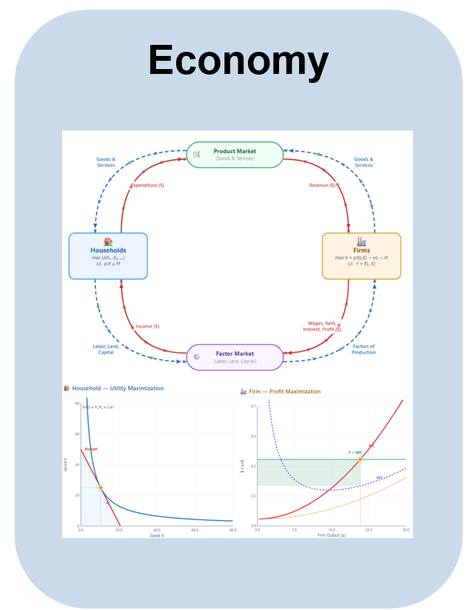

## The Problem with Traditional Economic Frameworks

### The Separation of Economy and Environment

The problem with traditional economic tools is that they were seen as separate from the environment. The origins of environmental economics thought about optimal extraction of various resources. This is important because resources are inputs to the economy, and this represents the old way of thinking, which is what natural resource economics is.

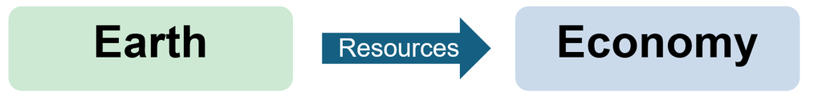

Natural resource economics focuses on how to optimally extract minerals from the ground, oil from the ground, or renewable resources like forests that regrow but should not be completely cut down. These are methods of optimally extracting things from the Earth for use in the economy.

### Environmental Economics as an Extension

A slightly less old approach is the environmental economics way of thinking. This still recognizes resources but adds a new consideration: wastes, like pollution. This is another thing that needs to be considered, but it is still an incomplete framework.

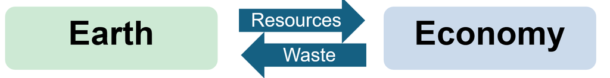

### The Embedded Economy Perspective

A better version does not have the Earth and the economy side by side. Western thinking often has a duality where the Earth and the economy are seen as separate, or humans and non-human things are seen as very different. This course will argue that this is the wrong way of thinking.

Instead, the economy should be thought of as embedded in the biosphere or the Earth. All flows are important, including resources flowing in and wastes flowing out, but it is not so simple. There are many complex linkages, and this should be thought of as a jointly determined system.

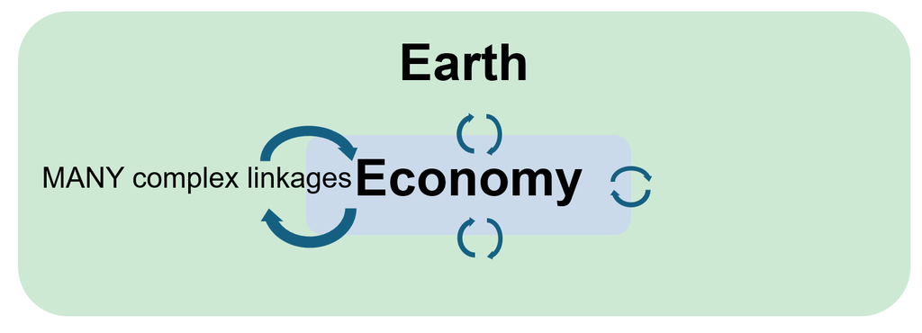

This is the reality. Climate change has helped express this as an important consideration, where essentially the economy has grown too big. The planetary boundaries concept can be simplified to say that our economy has gotten too big for the size of the biosphere, or more specifically, the regeneration capacities of the biosphere that create the fundamental opportunity to live as we do.

## Navigating the Anthropocene

### The Inadequacy of Current Navigation Systems

The problem is that we have no adequate navigational system. GDP as a navigational system and growth economics worked when the economy was small compared to Earth. But it is not so relevant when our problems have shifted from simply producing to not producing too much.

### Toward Earth Economy Models

This course is called Natural Resource Environmental Economics, but there is a petition to change the name. We are at a pivotal moment where, starting with climate change but now also considering many other simultaneous crises like the nature crisis and species loss, there is growing energy and excitement behind the idea that we need to create new models.

These models can be called Earth economy models. While the course will still cover the greatest hits expected in natural resource and environmental economics, the entire course is reformulated so that these are not separate things. Instead, the course recognizes how to tie them together with economy-wide models.

[figure not shown]

### From Microeconomics to General Equilibrium

Previously, this course was entirely microeconomics, thinking about optimal extraction, pollution taxes, and similar topics. Now that the economy has grown so large, the shift will be from microeconomics to general equilibrium and macroeconomics. The course will still include microeconomics, as micro and macro are fundamentally defined relative to each other, but navigating the Anthropocene requires a more general, general equilibrium.

Economists, especially at the PhD level, love general equilibrium because it means all parts of the economy are linked and it is so general that it includes everything. But it does not include everything; it does not include the assumptions of the system, such as those from the environment. Hijacking this language, we need to generalize this framework so it is not just general to all parts of the economy but a general, general equilibrium that also includes the Earth.

# Transcript

All right. Well, welcome, everybody. Why don’t we get started? Welcome to APEC 3611W. I’ll probably drop that W whenever I say it from now on. We’re going to talk about environmental and natural resource economics.

Today, I want to do what you probably expect on the first day of class. I want to talk about just an introduction to the content, a quick review of the syllabus, and a more detailed review of the schedule, but also give a big picture take on where we’re at with the environment in general, but also environmental and natural resource economics as a field. So let’s get started.

Just introducing myself here for a moment. I graduated with my PhD in the Department here of Applied Economics at the University of Minnesota in 2014. Immediately after graduating, I worked just down the hall, actually, at the Institute on the Environment. It’s in the Livestock Pavilion building, if you ever noticed that one. There, I worked for five years, first as a postdoc, and then a self-funded researcher for a while. It was kind of fun, although it was terrifying, because that meant I had to fundraise for myself, and if I didn’t succeed, I was fired. That’s never a fun position to be in. So now, I’m really happy that I made it back onto the faculty here in Applied Economics.

That was back in 2020 when I started here again, and I was just tenured last year, so now I can say whatever I want. Just kidding.

Other things I’ve done is I’ve worked extensively in this area, thinking about the environment and economics, and I’ve worked extensively with an organization that we’ll see and discuss many times throughout this, called the Natural Capital Project. More recently, we actually founded a spin-off organization of the Natural Capital Project. We call it NATCAP Teams, or The Earth Economy Modelers. That’s a departmental research center here in Applied Economics. We’re getting big and growing. It’s kind of fun to see it getting off the ground. It’s only been up for about a year and a quarter.

Besides Earth economy modeling, I’m also just interested in coding in general. I love it, and specifically the open source subset of coding. Especially in this age of AI, where we wonder what is the point of doing research when there are these AI agents who can also do research. I’ve come to the strong belief that the key thing for us is replicability and understandability of all the science that we do. For me, open source science is the correct answer, and this will actually be a theme throughout, because it’s fundamental to sustainability.

Okay, so that’s myself.

We have a great small class. I love this. I used to teach 1101 with some of you, that was a much bigger class that was more challenging to have discussion and stuff like this. This class will be very discussion-focused, and so let’s get to know each other. I’d like to just go around the room. I’d like you to take your time, we got time. Mention your name, of course, your major, where you are in the process towards graduating, or any other academic interests. Then what is the most beautiful place in nature you’ve ever been? This is environmental econ, so I hope at least there’s been one place that struck your fancy. Then, a quick mention of what courses you’ve taken as a background, and who taught them, if you’d like. That helps me understand the context of where we’re coming from. And then finally, what led you to take this course?

I know that’s a longer introduction than most, but we only have 19 registered people, missing a few this first day. I really want to get to know you.

[Student introductions occurred here, with students sharing their majors, beautiful places they’ve visited including Maui, the Dominican Republic, Iceland, Hawaii, Boundary Waters, Yosemite, and various state parks, along with their course backgrounds and reasons for taking the class.]

Welcome everybody. Did anybody not get the syllabus?

Excellent. It’s really good to get to know you. We might do another round of introductions at some point, just so that you all can get to know each other as well.

But I want to talk about the big picture. One of the questions was asking you why this course. There’s lots of good reasons, and I’m totally happy that it fits the graduation requirements, that’s the point of school. But I also am going to approach this course from the perspective that the environment matters. Saving the environment matters, and so I think you’re going to see a lot of passion from me coming out on this topic. If you did take my 1101, it probably even kind of snuck into that course a little bit, just because I can’t help it. This is a topic that I’m absolutely passionate about, and so I want to give a little bit of why I feel that way today. Or in other words, why we should care about the environment, but specifically from the perspective that economics brings.

We’re in a state of transition right now, but I want to give some historical context.

First off, I’m going to give a running disclaimer. If you have taken any of my previous courses, I am going to reuse some stuff, so just nod your head along with this. But what is this? This is a graph of the surface temperature on Earth for the last 100,000 years.

What do we see in this? Number one, wild swings. This is as glaciation happens, and the temperature swings up and down. It was actually quite a bit cooler before modern times. So really, it’s two things. It was cooler, and there were these massive fluctuations.

The Holocene is characterized by two things. Number one, a little bit warmer, but vastly more important, there were not dramatic swings in temperature. This led to a stability that many scientists call the Goldilocks Zone, where suddenly all sorts of things relevant to our current life started to emerge. Right here, that’s the beginning of agriculture. Here is the first great human civilizations, the Sumerians and the Egyptians. Nowhere in this earlier history did that exist.

We’re in kind of a unique, special Goldilocks zone here, and that’s, number one, really, really good, but number two, emphasizes the importance of staying in that region. There is reason to worry.

Some people even think and argue that we’re on the edge of going into a brand new ecological zone, leaving the Holocene and going into something called the Anthropocene. You know for sure it’s real if it’s reported in The Economist. We’re in an economics class, so what better form of proof of this concept being important is there than it being the cover of the keynote publication that economists tend to read?

I’m joking a little bit, there’s actually a fair amount of scientific debate of what actually counts as a geologic era, but we won’t get into that.

Instead, what I want to do is just highlight that we’re at a big moment of change, and I think I actually like this graph as the one for understanding a broad framing of the questions we’re going to address in this course.

This is kind of a fun three-dimensional plot here. What you can see is, number one, there’s the passage of time, basically moving towards the audience. That’s this axis here. Then there is stability, and it’s decreasing. Why is that? Well, if you think about where within a bowl would a marble be stable, it’s in the bottom of the bowl. So there’s a stable point here, a stable point here, big stable point here.

Then, finally, the key variable going left and right is the global temperature. Climate change is a big deal. That’s what changed to define the Holocene, and what we worry is changing with modern-day anthropogenic climate change. That’s going to be a fundamental basis of this course, adapting to that, understanding what that does to the sustainability of our economies.

A particular way we’ll look at it is thinking about it from the perspective of thresholds. That’s really what this graph is showing, the choices in front of us.

You could think of us as being right here, right now, where that Earth is. We have choices in front of us, such as how much should we emit? If we emit a lot, we’ll go towards this side, the hotter amount of climate change. But we also have options for stabilizing the climate and trying to push it in this direction.

The sort of scary possibility, though, is that there might exist, and there’s a lot of evidence that there do exist, feedback loops, where once you cross over some sort of threshold that is this dotted line here, the rate of change starts to accelerate, and we would then see this sort of split. We have an equilibrium where the world might end up down here in something called Hothouse Earth. Or, we could dodge that planetary threshold and start emitting a lot less right now, and end up in not ideal, but still a whole lot better of an equilibrium. It’s still the bottom of a bowl, so it’s still sort of stable, but we don’t have these high temperatures.

That’s really the framing that we’re going to use throughout this class, how do our decisions push us, not just on temperature, but on a whole variety of different things, towards different types of equilibria.

The one that will be seen throughout is this idea of planetary boundaries. Who’s heard of planetary boundaries as a concept?

It’s one of those ones that kind of is just barely making public recognition. There are some rock star statisticians, if that’s even possible, that talk about it. Johann Rockstrom, other people like that. Really compelling speakers, people that can give TED Talks about stuff like this, and really motivate people.

It’s been just one way of expressing the sort of peril that we might be in. In this particular case, here’s one of the recent papers, Earth Beyond Six of Nine Planetary Boundaries. Like, oh no, we should do something.

We could talk about the science behind each one of these different axes, but we won’t get into that. That’s more for an environmental science major. But it’s the ones you would expect. Climate change is a big one. Biospheric integrity, that’s another fancy way of saying biodiversity loss, or losing species. You can see genetic integrity, that’s kind of a key word for species. Land systems change is another one we’ll spend a whole lot of time talking about.

The point is, there is this safe operating space, this green area here. For a couple of them, we haven’t yet surpassed what they identified as the planetary boundary. But unfortunately for 6 of them, and there’s actually a more recent article that goes even further, we’re in this sort of tenuous space where we’re past the boundary and we’re kind of waiting for the other shoe to drop.

One thing I would say, though, is that this course is going to emphasize hopefulness. This one here, stratospheric ozone depletion. Who heard about the ozone hole?

You know what happened? We solved it. We had scientists who identified a problem. The ozone hole was being created by CFCs, a chemical used in refrigeration, and we came up with the Montreal Protocol, which solved it. It would have been a really awful thing if it did happen, like lots more skin cancer. But this is one of the planetary boundaries that has not been surpassed, and essentially it was because of successful collective action.

There are some reasons why other challenges are harder than that. That one was just one hole and one small spot and just one chemical involved. But other things like climate change might be much harder. But the point is, we can act collectively to solve these problems.

The key takeaway from this is that there are biophysical boundaries, and they should not be crossed, so we should tread carefully. In particular, in this class, we’ll talk about how our economy should not push these boundaries, and we’ll also be very specific about what are the costs to the economy from surpassing them.

This is a very popular framing, but I don’t really like it that much. I’m gonna use it because it’s so common, it’s just that I don’t find it very useful. It’s scary, yay, we’re scared. Now what? Well, at most, that could get you depressed, and depression doesn’t lead people to make positive change on the environment. It’s important to know the status, but it’s not very useful.

It’s also a little bit annoying to me in that it doesn’t have any information about what’s pushing these variables around, what’s causing us to possibly surpass the planetary boundaries.

I actually want to introduce the framing that we will talk about, and this is small for now, but don’t worry about it, we’ll dive deep into this in the next class. It’s called the Safe and Just Corridor, or also colloquially known as the Planetary Donut.

The idea is, we have planetary boundaries. You could also substitute in many other possible frameworks or different ways of measuring the planet, but basically things that we don’t want to do too much harm to. There is going to be, as you can see, some of them we’d be outside, some of them we’d be inside.

What the planetary donut adds to this is humans. The planetary boundaries is just the biophysical state of the world, but it doesn’t say anything about the underlying people, and the choices they make, and the well-being of those people in the system.

That’s what the donut, first introduced in 2017 by Kate Raworth, captures in a really nice way. She calls the planetary boundaries the ecological ceiling. But adds to it an important layer that she calls the social floor, or foundation.

You can see why it’s a donut, obviously, just the shape. But the idea is, for any of these indicators, we don’t want to go outside of the planetary boundary, but we also have to ask ourselves, are we producing the things that are necessary to create the social foundation? Next lecture, we’ll talk through those in detail, but things like producing enough food, having healthcare, a safe place to live. These are things that are produced by the economy.

We don’t want to do without them. This is a way of doing away with the idea that it’s the economy versus the environment, but rather, it’s jointly optimizing these trade-offs. There are certain types of economic activity that are really bad, like CFCs in refrigerants that caused the ozone hole. But there are also things that we really want, like universities. Or the option to have a safe and fulfilling, welfare-filled life. We’ll actually talk about what that means in economic terms.

The question that Kate Raworth talked about is what policies can we have that don’t fall below and undershoot on the amount of production of key things we care about, while also not having the problem of overshooting? Instead, how can we stay in the safe and just corridor?

There’s been all sorts of other work. In 2023, Kate Raworth published in Science the formal paper that describes this and quantitative metrics in detail. There’s all sorts of ways you can look at it. There are all sorts of other donuts. This has become a popular organizing principle.

I love this framework a lot more than just planetary boundaries by itself, because it includes the human. But it still drives me crazy, because even though it includes the human agents in this system, it doesn’t answer questions that are fascinating to me. Like, what should we do? What policies might get us into that safe and just corridor?

That’s going to be the framing throughout this class. Let’s analyze those policies. We need to understand the Earth’s systems at play so that we can be smart enough to figure out what sort of policies might work, or what sort of impact they’d have, but what are the actual levers we can pull?

I want to back up a second. This one is personal. What is the economist’s role in solving all this?

I bring this up because usually, I find myself talking to ecologists, or conservation biologists, or people like that that are less focused on economics as a discipline, and I feel like I’m always apologizing for economics. Who loves capitalism and unlimited economic growth?

Well, nobody wants to raise their hand. But who likes having tasty food? Yeah, okay, so there’s a tension here. A lot of the old way of framing environmental economics was the environment versus the economy, and this has been very successfully used by various interests in our society to polarize us and not care about some of the things that we actually do want to care about.

One of the sides of this polarization that I see, actually, is from the environmentalist side, just thinking that anything an economist says is going to be bad, because it’s about perfect markets, capitalism, endless growth and things like that. These are all things that are important to address, but actually, and I feel this strongly, economics is an incredibly useful lens to look at these questions.

So it’s not either/or. But regardless, I always feel like I’m apologizing for being an economist, and so I have these slides to talk about why economics has been really successful at what it was meant to do. This is also caveating that it has been problematic at things it wasn’t intending to do. So what is that?

Basically, economics did phenomenally well at improving physical consumption.

Where did modern economics get a start? You might be able to trace this back to right after World War II. We created systems of national accounts to define, among many other things, GDP.

Right now, everybody reports GDP constantly and obsesses with it. It makes and breaks presidents and policies. That was essentially a measure of how much can the economy produce. That’s really important when you’re in a wartime economy, and the success of your nation’s military depends on literally producing tanks, or something like that. It’s a good measure for the well-being that you could get from physical consumption.

We’re gonna return to these systems of national accounts, and we’re gonna extend them to include the environment. That’s just kind of like a preview.

These were navigational tools that were designed to help us make it out of the Great Depression. We’ll be learning a lot of those specific tools, like general equilibrium, growth models, supply and demand, basically, or the circular flow diagram that you maybe were exposed to in Econ 1101.

The result of this, it’s really easy to forget how big of a change we’ve had in the last 100 years. Let me just throw up some statistics. Producing more stuff. Why is that good? Well, it is, if distributed properly, something that can reduce poverty.

Here is the world population living in extreme poverty from 1820 to 2015. Here’s the depression. You can see this is a drastic change. If you were in this earlier era, the odds that you would be struggling to have enough calories to survive would be 90% or more. Looks like more like 95%. But now, it’s the other way around, and if this graph continues, we’ve had a drastic reduction in poverty.

Maybe you could debate that one. Like, what is poverty? Is consuming things really the answer? Well, let me give you one that I don’t think you can debate. We are living longer. That’s just factually true.

Here are life expectancies at birth, plotted from 1770 to 2021, and you can see, again, at about that same point, all of these started accelerating upwards. There’s been obvious lags in one region versus another region, so basically high-income countries are way higher on this than Africa. What do you see here? What’s this little dip?

Yeah, COVID. It started going back up again, but not as fast as we’d like.

This is also consumption, it’s just healthcare consumption. Clean water, sanitation, access to medical services. That’s, I think, really telling, because if you look at, in America, what was the life expectancy at the turn of the century, it was 42 years.

That wasn’t that long ago, and 42 years is not that old. It’s relevant to me, because I’m 43 years old. Every year I update this, and last year when I got to show this slide, it was exactly my age. Well, now I’m dead. No, kidding. But the point is, this is not debatable. There’s no way you can debate these statistics. You might be able to argue, is it good or bad? Is it worth it? Is it not? But I’m pretty happy I’m still alive here. I’m happy for this trend upwards that we see, and it really is a dramatic shift.

You can go further on this. Less homicides. One of the most controversial books in the last while was written by Stephen Pinker. It’s called The Better Angels of Our Nature. It was a detailed statistical accounting from an anthropologist on how, he argues, our world is getting less and less violent. There’s some outliers, like notably World Wars I and II, but overall, the probability that you will die a violent death seems to be going down.

I actually read this book right in 2016. I was feeling depressed about the state of the world, and I decided I needed a pick-me-up, so I wanted to read the most optimistic book I could. Bad choice. The whole first half of the book is the history of violence. That’s sort of depressing, it turns out. We watched torture as a thing, like public execution, and people didn’t feel weird about this. I think we’ve made some changes for the better on that.

Okay, so those are the indicators, but what did economics specifically do? Well, we built tools that describe the economy. It was rather successful. The way we’re going to be shifting our thinking is discussing some of the specific tools that fit within this box economy, and address how they do a good job or bad job of simultaneously accounting for the value of nature and the value of producing things that we like.

But I just want to first talk about its successfulness overall in the economic domain. Here’s an interesting plot. This is time, and obviously it’s too small to see, but I’ll walk you through it. The U.S. has experienced 34 recessions since 1855, and they’re going to be denoted by pink. The blue areas are the areas where we’re not in recession.

What do we see? There’s a whole lot of recessions for the left side of this graph. Starting again at about that same point, this is what’s referred to as the Great Moderation in economics. There’s huge and contentious debates about what caused this moderation, but it does appear to be the case that we have less fluctuation towards the negative side on our economic cycles.

One of the also very contentious arguments is that economics provided tools to understand how do economies grow, how does inflation happen, how can we manage those things.

You can spend a whole other course debating this point, but it remains, I think, evident that there has been this broad proliferation of tools that economists use to try to better manage the economy. All the various levers that we could pull, like exchange rates, printing of money, things like that, are ones that might and I would argue do, in fact, contribute to this stabilization of our economy.

So they’re good, and what are those tools? The things you learned in your other econ classes. Here’s just one example that combines a whole bunch. There’s a production possibilities curve with a price line. You probably didn’t learn the contract curve, but you can dive deep. Did anybody have an Edgeworth box in any of their classes?

A little bit. That’s this inner part here with the squiggly lines. It’s one of those things that they used to always teach, but I think they’re moving away from it. You won’t learn it in this class. But it’s one of the more hard things to understand. It’s how two people might exchange things in an economy to maximize their surplus happiness.

This is what we will return to. We’ll be talking about how do individuals make decisions. We’ll use environmental decisions as the context, but we’ll use the basic tools of economics.

That’s at the micro level. This is like a summary of the greatest hits of micro econ. Down here, this is like a summary of the greatest hits of macroecon. This is the circular flow diagram, talking about how households buy goods and services from businesses in the products market, but that they also provide inputs to those companies in terms of their labor. We’ll get into this. This is the sort of tools that we’re gonna see.

The problem that I have, and that we’ll address throughout this course, is that these tools were seen as being separate from the environment.

It might look a little bit like this. The origins of environmental economics really thought about it from the point of view of how do you extract various resources. That’s important because those are inputs to the economy. This is the old way of thinking about it. This is what natural resource economics is.

That’s one of the words in our course title, right? We’re Environment and Natural Resource Econ. The origins of this is thinking about how do we optimally extract minerals from the ground, or oil from the ground, or maybe they’re renewable, and it’s a forest that regrows, but we don’t want to cut it all down, because then it doesn’t grow back. These are ways of optimally extracting things from the Earth to be used in the economy.

A slightly less old one is to think about it in the environmental econ way of thinking. That’s the other word within our title.

So we have the Earth and the economy, and it adds a new arrow. It still recognizes we have resources, but we also have wastes, like pollution. That’s another thing that needs to be considered. It’s slightly less old.

But you might tell by my framing that I still don’t think that’s sufficient.

A slightly better version is not to have the two things side by side. There’s this duality very common in Western thinking, so take a philosophy course, you’ll appreciate the deepness of the thinking here, that the Earth and the economy are separate, or that humans and non-human things are somehow very different.

I’m gonna argue throughout this whole class that that’s the wrong way of thinking about it, that instead we think about it as the economy is embedded in the biosphere, or the Earth. All these flows are important. You still will have resources flowing in, and wastes flowing out, but it’s not so simple. There are many complex linkages, and we want to think about this as a jointly determined system.

That’s the reality. I think things like climate change started to express this as an important thing that we needed to take into account, where essentially the economy grew too big. The whole planetary boundaries thing can be simplified down into our economy’s gotten too big for the size of the biosphere, or more specifically, the regeneration capacities of that biosphere that create the fundamental opportunity to live like this.

The problem, I would argue, is that we have no adequate navigational system. GDP as a navigational system, and our growth economics, that worked when the economy was small compared to Earth. But it’s not so relevant when our problems have shifted to some of producing, yes, but not producing too much.

The course that we’re going to have here, it is called Natural Resource Environmental Economics, but I’m going to petition for the next year to change it, now that I’ve taken over this course. I think we’re at a pivotal moment where, starting with climate change, but now also considering many other simultaneous crises like the nature crisis or species loss, we are in a situation where there’s growing energy, excitement behind the idea that we need to create new models.

I’m going to call these earth economy models. Although we’ll still talk about the sort of greatest hits that you would expect in natural resource and environmental economics, this whole course is going to be reformulated so that those aren’t just separate things. Instead, it’s going to recognize how we can tie them together with economy-wide models.

To summarize, before, this course was entirely microeconomics, thinking about optimal extraction, or pollution taxes, or stuff like that. But now that the economy has grown so big, we’re gonna switch from microeconomics to general equilibrium and macroeconomics. It’ll still have microeconomics, they’ll be fundamentally defined relative to each other, but I’m going to argue that to navigate the Anthropocene, we need a more general, general equilibrium.

Just to give a note on why I’m smirking there, economists, especially once you get into the PhD level, they love general equilibrium. It just means, and we’ll get into this, that all parts of the economy are linked, and they love it. It’s so general, it includes everything.

But it doesn’t. It doesn’t include the assumptions of the system, such as those from the environment. Hijacking their language, we need to generalize this out. So it’s not just general to all parts of the economy, but a general, general equilibrium that also includes the Earth.

So the syllabus, you’ll find it online. I took a little bit longer than I wanted to here, so I’m gonna go quickly.

It’s as you’d expect, so I don’t want to spend too much time on this. We got learning objectives.

One thing I will say is I’m going to be recording all these classes. However, attendance is still required. It’s 10% of your grade, and we’ll talk more about that next class, how I’m going to record that. The recordings are there for your reference, but don’t use them as a substitute for coming in person. Unless you have a legitimate excuse, you will lose points, because this is important.

I also want to say, let me know if you’re not okay with me recording these. My goal is to put them on YouTube. I’m trying to create a massive online open course with this content to start to fill it out. The camera will always be on me. Your voice might get into here, but your image won’t. If you say anything that you don’t want, or you just feel uncomfortable about this, reach out to me now, before I post anything.

It’s in person. Oh yeah, the textbook. Eventually, I’ll be writing an open access textbook on this topic, but for now we’re using this one, which is free through the U of M libraries. I think you have to be logged in to access it, so if that throws up a flag, that’s why, but it’s at that link.

The final thing maybe to note is that there’s going to be the Canvas page, yes, but I actually don’t want to use the Canvas page very much. It’s only going to be for announcements, assignment submission, and grade reporting, but I hate Canvas. Why? Well, everybody hates it, but more specifically, because it’s proprietary. It’s a closed system. It’s not freely editable by anybody.

Instead, what we’re going to use is our course website. I’ll refer to the course Canvas page, but then the first thing it does is link to the course website. There’s Canvas, but not much will be on here. You still will submit things, assignments there. But it just links to our course website. You’ll find that’s where you can get the actual syllabus.

I used to be a web designer, so that’s why everything is on my personal website.

Really, the critical thing is the schedule. This will be updated. The topics that we have and the specific dates, they may change a little bit. The ones that won’t change are the dates of the midterm and the final, so that you can schedule. This is an interactive course, and based on student interest, we may reorganize the topics. As we go, we’ll be filling up links here.

The readings for the next class, Friday, are there. There’s two here. It’s a really quick read on donut economics, and the details of it, and an optional longer reading on it. We’ll also populate this with videos and slides, and any notes on assignments are going to be here.

I really didn’t get through all the parts of the syllabus today, because I kind of got long-winded, which I’m tended to do. So I might hit on a few points next class.

Other than that, I’m excited. You’re free to go. Feel free to ask me any questions. We’ll kick off where we left off. Do make sure you read that Donut Economics website. Thank you.

# Appendix

## Learning objectives

After this chapter, you should be able to:

- Explain why many environmental problems are **economic problems** (scarcity, tradeoffs, incentives, institutions).
- Defend economics as a **toolkit** for environmental goals (not a value system).
- Distinguish (i) **externalities**, (ii) **public goods**, and (iii) **common-pool resources**, and name a plausible policy response for each.
- Describe what a “**marginal**” argument is (marginal benefit vs marginal cost) and why it matters for policy design.
- Preview the Earth–economy modeling idea: “everything depends on everything,” including the biosphere.

## Core idea: environmentalism needs a theory of human behavior

If you care about climate, biodiversity, clean water, or land-use change, you are implicitly making claims about:

- what people want and need,
- what constraints they face,
- what rules shape their choices,
- and how those choices aggregate into outcomes.

Economics is useful because it provides a disciplined way to talk about those four things **without needing everyone to be altruistic**.

A blunt way to say it:

> Environmental problems are often “good intentions meeting the wrong incentives.”

Economics helps you redesign the incentive environment—laws, prices, norms, enforcement—so that individually rational choices can become collectively sustainable outcomes.

## What economics is *and is not* (for environmentalists)

### Economics is:

**A way of thinking**, built around: - **Scarcity**: not enough of everything for everyone, always. - **Tradeoffs**: choosing more of one thing means choosing less of another. - **Incentives**: people respond to costs and benefits (not just money). - **Institutions**: rules, property rights, and governance shape what “pays.”

### Economics is not:

- a moral claim that nature only matters if it has a price,
- a claim that markets always work,
- or a claim that GDP growth is the goal.

Economics can be used in service of many value systems. In this book, we’ll use it to support **global sustainability** and **human well-being within ecological limits**.

## A fast tour of the “big three” environmental problem types

Environmental and natural resource economics often begins by classifying problems into three types. The classification matters because it points to different solutions.

### 1) Externalities (spillovers)

**Definition:** Your action imposes costs (or benefits) on others that you do not pay (or receive).

- Example: CO₂ emissions warm the planet; emitters don’t pay the full cost.
- Why it persists: private incentives ≠ social incentives.

**Common fixes (toolkit preview):** - Pigouvian taxes (e.g., carbon tax) - cap-and-trade (tradable permits) - performance standards - liability and enforcement

### 2) Public goods (non-rival, non-excludable)

**Definition:** One person’s use doesn’t reduce availability to others, and it’s hard to exclude non-payers.

- Example: basic climate stability, many forms of knowledge, some ecosystem protection benefits.

**Why it persists:** free-riding makes markets underprovide.

**Common fixes:** - public provision (government funding) - collective action agreements - innovation policy / R&D subsidies

### 3) Common-pool resources (rival, hard to exclude)

**Definition:** Your use reduces what’s left, and it’s hard to stop others from using it.

- Example: fisheries, groundwater basins, some forests, congested airsheds.

**Why it persists:** “race to extract” dynamics.

**Common fixes:** - community governance with enforceable rules - catch shares / quotas - spatial zoning and monitoring - clarified and enforceable rights (not necessarily privatization)

## Marginal thinking: why “more” isn’t the same as “better”

A lot of environmental debates stall because people argue about *totals*.

Economists ask: **“What happens at the margin?”**

- Marginal benefit (MB): the benefit of a *little more* of something.
- Marginal cost (MC): the cost of a *little more* of something.

For pollution control, the classic framing is:

- **Marginal damage (MD)** rises with more pollution (more harm at the margin).
- **Marginal abatement cost (MAC)** rises with more abatement (harder reductions cost more at the margin).

A serious policy aims to reduce pollution until:

> **MAC ≈ MD**

That’s the intuition behind “efficient” policy in the *narrow* sense.  
But “efficient” is not the same as “just,” “politically feasible,” or “ecologically safe.” We’ll build those layers later.

## Worked example: why a tiny fee can beat a big moral appeal

Suppose a city wants to reduce single-use plastic bags.

**Option A: Moral appeal** - Posters: “Please use reusable bags.” - Some people comply, many don’t.

**Option B: 10-cent bag fee** - Not because 10 cents is huge, - but because it changes the *default* and makes the decision salient at the moment of choice.

Economics prediction: even a small price signal can create a large behavior change when: - the alternative is easy (bring a reusable bag), - people are forgetful, - and decisions are made quickly.

Key lesson: policy often works by changing the **choice architecture** and the **relative payoffs**, not by changing who people are.

## Why the “Earth-economy” framing matters

Traditional economics often treats the environment as: - a sector, - a constraint, - or an externality.

An Earth–economy view treats the economy as **embedded in** the biosphere:

- Natural capital (ecosystems, climate, soils) is not just “amenities.”
- It is *productive infrastructure* that supports lives and livelihoods.
- Degrading that infrastructure can create **systemic risk** (economic instability and irreversible losses).

This is why the book moves from: 1. micro tools, 2. to macro measurement and inclusive wealth, 3. to natural capital and institutions, 4. to integrated Earth–economy modeling.

## Open resources you can legally remix into this textbook

This book is meant to be a remixable CC BY-NC-SA Quarto text. These sources are explicitly compatible.

### Core remix sources (CC BY-NC-SA)

- **Principles of Economics (Open Textbook Library; UMN Libraries Publishing, CC BY-NC-SA)**
  - https://open.umn.edu/opentextbooks/textbooks/principles-of-economics
  - (You can adapt chapters/figures; attribution required.)
- **MIT OpenCourseWare (CC BY-NC-SA 4.0)**
  - OCW license page: https://ocw.mit.edu/pages/privacy-and-terms-of-use/
  - 14.42 Environmental Policy and Economics (Spring 2011): https://ocw.mit.edu/courses/14-42-environmental-policy-and-economics-spring-2011/
- **InTeGrate Teaching Materials (SERC/Carleton; designed for reuse; commonly CC BY-NC-SA with item-level provenance)**
  - Browse materials: https://serc.carleton.edu/integrate/teaching_materials/index.html
- **Natural Resources Sustainability: An introductory synthesis (CC BY-NC-SA 4.0)**
  - https://uen.pressbooks.pub/naturalresourcessustainability/
  - License statement appears in the back matter: https://uen.pressbooks.pub/naturalresourcessustainability/back-matter/appendix/

### Reading-only (open access but not remix-friendly for derivatives)

- **CORE Econ – The Economy 2.0** is open access, but its posted license is **BY-NC-ND** (no derivatives), so treat as *reading* rather than remix content:
  - https://www.core-econ.org/terms-of-use/
  - https://books.core-econ.org/the-economy/

## Exercises

1. **Classify the problem (one paragraph each).**  
   For each case, identify whether it is primarily an externality, a public good problem, or a common-pool resource problem—and justify your answer:
   - 1. Overfishing in a coastal region
   - 2. Global climate stability
   - 3. Urban air pollution from traffic
2. **Tool-to-problem matching (short answers).**  
   Pick one policy instrument for each case above and explain *why* it fits the problem type.
3. **Margins in plain language.**  
   Explain in your own words what “marginal” means, using **either**:
   - pollution reduction, **or**
   - forest conservation, and give an example where “more” could have diminishing returns.
4. **Earth–economy preview (reflection).**  
   Describe one way biodiversity loss could create economic risk **without** passing through market prices.

## Connections to later chapters

- The “big three” classification (externality/public good/commons) is the map for Chapters 3–5.
- GDP and “beyond GDP” measurement comes in Chapters 6–9.
- Natural capital, institutions, and governance take center stage in Chapters 10–12.
- Earth–economy modeling (integrated feedbacks) begins in Chapter 17.